# Assignment04 - Economic Opportunity and Upward Mobility in the United States

Exploring Economic and Social Conditions Across the U.S. Counties

Author

Jonas Wenner (jw2558)

## Data

**Data Source:** The data used in this analysis and visualizations come from the ‘Urban Institute’s Upward Mobility Framework’. The dataset contains longitudinal county-level measures related to economic and social conditions in relation to upward mobility in the U.S. (URL:https://datacatalog.urban.org/dataset/mobility-metrics-data-upward-mobility-framework)

```r
# Instruction to not use scientific notation
options(scipen = 999)

# Loading the necessary packages
library(tidyverse)
library(ggplot2)

# Loading the data into folder using Assignment02 method
mobility_link <-
  paste0("https://urban-data-catalog.s3.amazonaws.com/drupal-root-live/2026/06/03/11_mobility-metrics_county_longitudinal.csv")

if (!file.exists("11_mobility-metrics_county_longitudinal.csv")) {

  download.file(mobility_link,
                 destfile = "11_mobility-metrics_county_longitudinal.csv")
}

# Loading the data into the global environment
mobility <- read_csv("11_mobility-metrics_county_longitudinal.csv")

# Taking a glimpse into the data
glimpse(mobility)
```

## Visualization 1 - Changes in Employment Across U.S. Counties

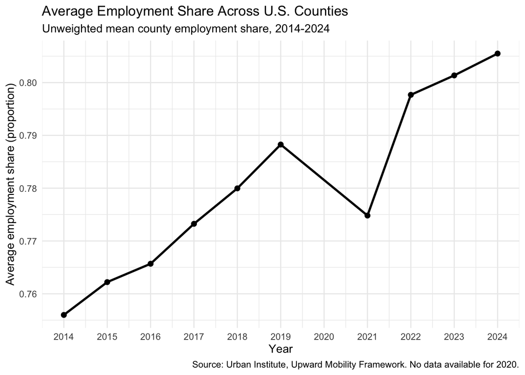

```r
# Filtering NAs from 'share_employed', calculating the mean by
# year and visualizing the average employment share over time with a line graph
mobility |>
  filter(!is.na(share_employed)) |>
  group_by(year) |>
  summarize(
    mean_share_employed = mean(share_employed)
  ) |>
  ggplot(mapping = aes(x = year, y = mean_share_employed)) +
  geom_line(linewidth = 1) +
  geom_point(size = 2) +
  scale_x_continuous(
    breaks = 2014:2024
  ) +
  labs(
    title = "Average Employment Share Across U.S. Counties",
    subtitle = "Unweighted mean county employment share, 2014-2024",
    x = "Year",
    y = "Average employment share (proportion)",
    caption = "Source: Urban Institute, Upward Mobility Framework. No data available for 2020."
  ) +
  theme_minimal()
```

**Interpretation:** The average employment share across U.S. counties increased from ~76% in 2014 to >80% in 2024. The increase remains relatively consistent until 2019, then falls in 2021 before rising again through 2024. Since the measure captures an unweighted county average, the visual highlights changes in the average rather than the employment share of the total U.S. population. Hence, while it suggests an improving employment situation, it cannot explain whether these opportunities are distributed evenly across counties. Therefore, policymakers need to consider geographic differences to identify counties that may not have benefited equally from the increase, instead of relying on overall averages.

## Visualization 2 - Differences in Household Income Across U.S. Counties

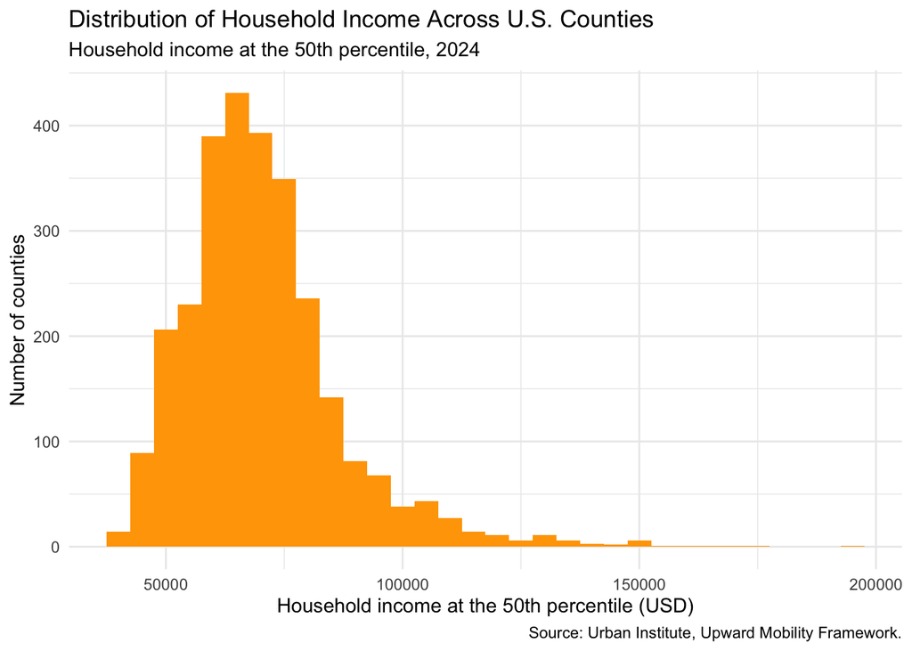

```r
# Filtering for 2024 and non-missing pctl_income_50 values and visualizing
# the distribution of household incomes across counties with a histogram
mobility |>
  filter(year == 2024,
         !is.na(pctl_income_50)
         ) |>
  ggplot(mapping = aes(x = pctl_income_50)) +
  geom_histogram(binwidth = 5000, fill = "orange") +
  labs(
    title = "Distribution of Household Income Across U.S. Counties",
    subtitle = "Household income at the 50th percentile, 2024",
    x = "Household income at the 50th percentile (USD)",
    y = "Number of counties",
    caption = "Source: Urban Institute, Upward Mobility Framework."
  ) +
  theme_minimal()
```

**Interpretation:** In 2024, household income varied considerably across U.S. counties, while the histogram suggests most are concentrated around the center of the distribution at around 60-70k. Importantly, the distribution is right-skewed, with a small number showcasing a substantially higher 50th-percentile household income compared to most other counties. Although the first visualization shows an overall improvement in employment, this histogram suggests that economic conditions differ considerably across counties. These geographic differences suggest that general national trends alone may hide important differences in local economic opportunities for citizens. For policymakers, this underlines the necessity to consider local economic conditions when designing policies aimed at improving economic opportunities.

## Visualization 3 - Employment and Household Income Across U.S. Counties

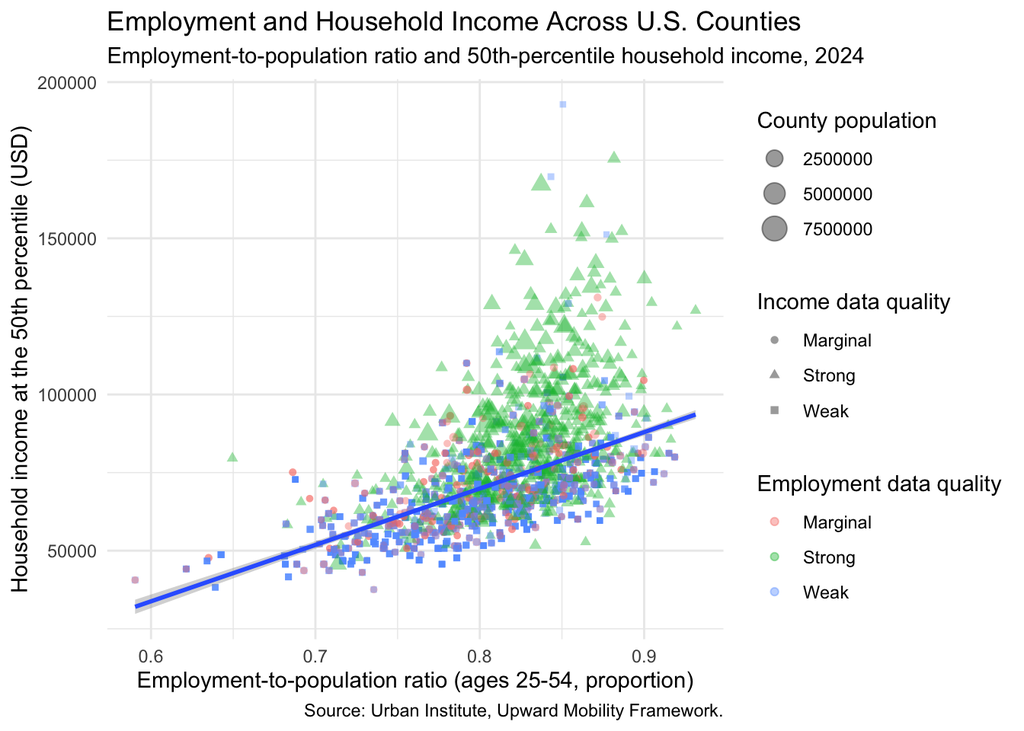

```r
# Filtering for 2024 and non-missing 'share_employed' and 'pctl_income_50'
# values, then visualizing their relationship
mobility |>
  filter(
    year == 2024,
    !is.na(share_employed),
    !is.na(pctl_income_50)
  ) |>
  ggplot(mapping = aes(x = share_employed, y = pctl_income_50)) +
  geom_point(mapping = aes(
    size = population,
    color = share_employed_quality,
    shape = pctl_income_50_quality),
    alpha = 0.4) +
  geom_smooth(method = "lm") +
  scale_size_continuous(
    breaks = c(2500000, 5000000, 7500000)) +
  labs(
    title = "Employment and Household Income Across U.S. Counties",
    subtitle = "Employment-to-population ratio and 50th-percentile household income, 2024",
    x = "Employment-to-population ratio (ages 25-54, proportion)",
    y = "Household income at the 50th percentile (USD)",
    color = "Employment data quality",
    shape = "Income data quality",
    size = "County population",
    caption = "Source: Urban Institute, Upward Mobility Framework."
  ) +
  theme_minimal()
```

**Interpretation:** The scatterplot highlights that in 2024, a positive relationship between employment and household income exists across U.S. counties. Counties with higher employment-to-population ratios seem to have higher household incomes at the 50th percentile. Nevertheless, there is variation in household incomes when comparing counties with similar employment levels, thereby indicating that employment cannot explain varying outcomes. Point size represents county population, while color and shape indicate the data quality of the employment and income measures. While the relationship cannot be interpreted as causal, it suggests that policies targeting employment opportunities need to consider other local factors that may influence incomes.

## Visualization 4 - Housing Affordability Across Income Levels

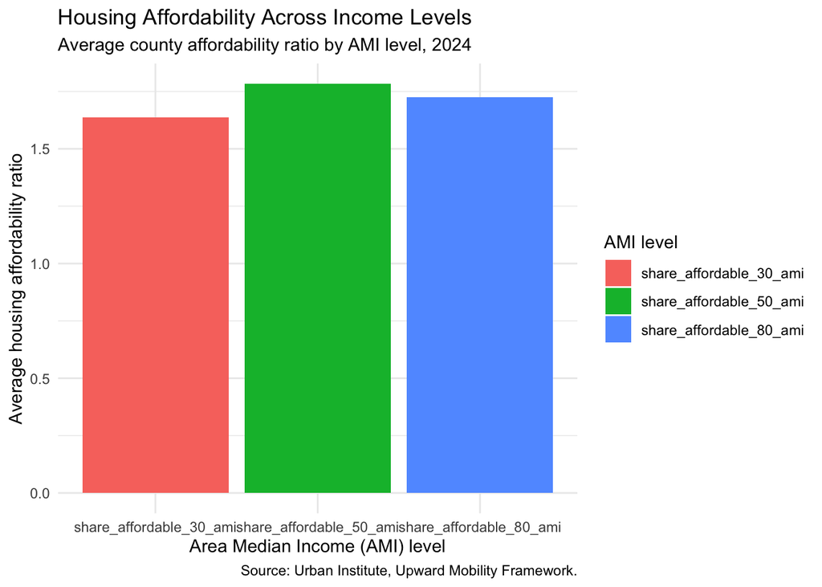

```r
# Reshaping the three housing affordability variables into a longer format to
# compare affordability ratios across AMI levels
housing_longer <- pivot_longer(
  data = mobility,
  cols = c(
    share_affordable_30_ami,
    share_affordable_50_ami,
    share_affordable_80_ami
  ),
  names_to = "ami_level",
  values_to = "affordability"
)

# Filtering for 2024 and non-missing 'affordability' values, calculating the mean by AMI level, and visualizing the average affordability ratios with a barplot
housing_longer |>
  filter(
    year == 2024,
    !is.na(affordability)
  ) |>
  group_by(ami_level) |>
  summarize(
    mean_affordability = mean(affordability)
  ) |>
  ggplot(mapping = aes(x = ami_level, y = mean_affordability, fill = ami_level)) +
  geom_col() +
  labs(
    title = "Housing Affordability Across Income Levels",
    subtitle = "Average county affordability ratio by AMI level, 2024",
    x = "Area Median Income (AMI) level",
    y = "Average housing affordability ratio",
    fill = "AMI level",
    caption = "Source: Urban Institute, Upward Mobility Framework."
  ) +
  theme_minimal()
```

**Interpretation:** The barplot shows the differences in the average housing affordability ratio across three income levels in U.S. counties in 2024. The shown ratio is lowest for households at the 30% AMI level, increases at the 50% AMI level, and slightly decreases at the 80% AMI level. This suggests that, rather than following the same pattern for all income groups, housing affordability conditions are different depending on household income levels. For instance, the lower ratio at the 30% AMI level highlights that the lowest-income households are facing different housing affordability conditions than those at higher levels. For policymakers, these variations are crucial to determine policies aiming at improving access to affordable housing, while considering different income levels.

## Conclusion

Overall, the four visualizations highlight that economic opportunity varies greatly across U.S. counties and cannot be captured by a single indicator. While average employment has increased over the past years, great differences in household income remain across counties, and employment as an indicator cannot explain these differences alone. In addition, housing affordability conditions also highlighted variation across income levels, hence adding another dimension for measuring and determining varying levels of economic opportunity for researchers and policymakers. Together, the visualizations underline the importance of considering a wide variety of local economic and social conditions when designing and passing policies aimed at improving upward mobility.